# TP De Probabilités de OWONA FOUDA Jean Edouard (2223M425)

OWONA Edouard

04/02/2023

**But du TP** : L’objectif de ce projet est d’évaluer les compétences de chaque étudiant à écrire des codes de simulation de variables aléatoires quelconque et leur intégration dans des modèles divers pour analyse. Il a été vu plusieurs méthodes de simulation de variables aléatoires parmi lesquelles le changement de variable et la méthode d’inverse de la fonction de répartition.

On fait l’étude sur la modélisation de la croissance en diamètre (en $cm$) d’un arbre au sein d’une forêt. $X_k$ (k correspond à une année) est le diamètre (en $cm$) à l’instant k, la suite $X_0, X_1, · · · , X_k$ (encore notée ($X_k$)$k≥0$) est un processus (de Markov) qui modélise l’évolution annuelle du diamètre d’un arbre. Le diamètre à l’instant $k$ dépend de celui à l’instant $k − 1$, ainsi, la loi de transition de $X_{k−1}$ vers $X_k$,$k ≥ 1$ est inspirée d’un modèle de croissance celui de **Gompertz* [Gom25] et peut s’écrire comme suit :
$$X_k = D^{1-exp^{-r}}(\frac{X_{k-1}+X_{k-2}}{2})^{exp^{-r}}\epsilon_{k-1}$$
, pour $k \ge 1$

ou $r$ et $D$ représentent respectivement le taux de croissance et le diamètre maximal d’un arbre. Dans la suite, prendre $r = 0.3$ et $D = 150cm$. $\epsilon_k$ est le bruit du modèle et on suppose qu’il peut être modélisé par la loi exponentielle (de paramètre $\theta$) de densité :

$$f(x) = \begin{cases} 0 & si & x<0\\ \theta e^{-\theta x} & si & x ≥ 0\end{cases}$$

On suppose que $X_0$ et $X_1$ sont choisis de telle sorte que le vecteur $(X_0,X_1)$ suit une loi multinormale $\mathcal{N}(\mu,Q)$ avec :
$$f(x) = \begin{cases} \mu = (10.,12.)^T\\ Q = \begin{pmatrix} 1.1^2 & .5^2 \\ .5^2 & 1.1^2 \end{pmatrix} \end{cases}$$

```r
# chargement des packages nécessaires
library(MASS)

# creation des constantes
r = 0.3
D = 150
k_max = 50
# theta représente le paramètre theta
theta_test = 10

# limite d'axes utilisée dans certains graphiques
lim = 10
# Notre numéro sur la liste officielle (OWONA Edouard)
numListe = 15

# paramètres de la loi multi-normale
# vecteur des moyennes
mu = c(10.,12.)
# matrice de variances-covariances
c11 = 1.1^2
c12=.5^2
Q = matrix(c(c11,c12,c12,c11),ncol = 2)

# initialisation du seed
set.seed(numListe)

# on suppose l'année initiale 2023
anInit = 2023
```

# En utilisant la méthode de l’inverse de la fonction de répartition, écrire un simulateur de la loi du bruit $\epsilon_k$ décrite plus haut. En plus de ce simulateur, fournir un code pour le calcul de la densité, de la probabilité et des quantiles de cette loi. Votre rapport doit inclure les étapes d’obtention de l’inverse de la fonction de répartition.

Au préalable, il est nécessaire de calculer $F$ et $F^{-1}$ afin d’écrire le simulateur du bruit. Après calculs usuels sur la fonction de répartition, on obtient: Par définition, nous avons :

$F(x) = \mathcal{P}(X≤x) =\int_{-\infty}^{x} f(t)dt = \int_{0}^{x} f(t)dt$, ce qui donne :

- Si $x<0$, alors $F(x) = 0$
- Si $x ≥ 0$, alors $F(x) =\int_{0}^{x} f(t)dt = \int_{0}^{x} \theta e^{-\theta t} dt =[-e^{-\theta t} ]^{x}_{0} = 1- e^{-\theta x}$

D’ou en resumé:
$$F(x) = \begin{cases} 0 & si & x<0\\ 1- e^{-\theta x} & si & x ≥ 0\end{cases}$$

Enfin procédons au calcul de l’inverse de la fonction de répartition ci-dessus :

Posons : $y = F(x) = 1 - e^{-\theta x}$,

On aura : $e^{-\theta x} = 1-y$, en composant par $ln$ ($ln$ strictement croissante) de part et d’autres, il vient

$-\theta x = ln(1-y)$, il vient : $x = -\frac{ln(1-y)}{\theta}$

Nous en déduisons l’écriture ci-dessous de l’inverse de $F$ si $x \in [0;1[$

$$F^{-1} (x) = -\frac{ln(1-x)}{\theta}$$

Par la suite, nous allons implémenter ces fonctions dans la section de code ci-dessous.

```r
# cette section est consacrée au code des quatres principales fonctions associées à une variable
# aléatoire dans R

#  fonction de répartition de d'epsilon le bruit
FEpsi = function(x,theta){
  if(x<0){
    # cas 1 de la fonction de répartition, dans ce cas F n'est pas définie
    return(0)
  }
  else{
    # cas 2 de la fonction de répartiton
    return (1-exp(-x*theta))
  }
}

# Fonction inverse de la fonction de répartition
invEpsi = function(x, theta){
  # theta doit être strictement positif bien entendu
  if((x>=0)&&(x<1)&&(theta!=0)){
    # on calcul l'expression à retourner
    p = -log(1-x)/theta
    return(p)
  }else{
    # dans le cas contraire la fonction n'est pas définie et on retourne 0
    return(0)
  }
}

# fonction pour avoir la quantile d'ordre q
qEpsi = function(p, theta){
  # car q = F^-1(p) et p = F(q)
  return(invEpsi(p,theta))
}

# fonction pour avoir une probabilité à base d'un quartile q
pEpsi = function(q, theta){
  return(FEpsi(q,theta))
}

# fonction densité
dEpsi = function(x, theta, log=FALSE){
  if((x>=0)){
    # Calcul de l'expression principale d'une loi exponentielle
    y = theta*exp(-theta*x)
    if(log==TRUE){
      # Si l'option du logarithme est activée (pour le cas du maximum de vraissemblance par exemple)
       return(log(y))
    }else{
      # Dans le cas contraire, on retourne l'expression naturelle de la loi exponensielle
      return(y)
    }
  }else{
    return(0)
  }
}

# fonction pour générer les nombres aléatoires tirés de notre loi exponentielle
rEpsi = function(n, theta){
  # Ayant utilisé la méthode de l'inverse, il est naturel de faire appel à la loi uniforme
  # définie dans  [0,1] afin de générer des nombres aléatoires
  return(invEpsi(runif(n), theta = theta))
}


# Cette fonction permet de générer un vecteur contenant les données d'une trajectoire
# pour une simulation donnée
generateTrajectory = function(epsi){
  # epsi représente le vecteur de bruit qu'on choisit dès le départ
  # On crée un vecteur avec les valeurs initiales des diamètres des arbres
  # suivant une loi multinormale
  X_0_1 = mvrnorm(n = 1, mu = mu, Sigma = Q)

  # On repète ces valeurs 50 fois car notre vecteur a une taille de 2
  # et il nous faut 50 valeurs initiales
  # X est le vecteur des valeurs initiales suivant une loi normale
  X = rep(X_0_1, k_max/2)

  # il faut débuter à 3 car le terme courant dépend des deux termes précédents
  for(i in 3:k_max){
    X[i] = (D^(1-exp(-r))*((X[i-1] + X[i-2])/2)^(exp(-r)))*epsi[i-1]
  }
  # On retourne X le vecteur modifié et contenant les valeurs simulées en accord avec le
  # modèle
  return(X)
}

# cette fonction permet de générer une trajectoire mais avec un bruit interne
# qu'on ne passe pas en paramètre

generateTrajectories = function(theta){
  # epsi représente le vecteur de bruit qu'on choisit dès le départ
  # On crée un vecteur avec les valeurs initiales des diamètres des arbres
  # suivant une loi multinormale
  X_0_1 = mvrnorm(n = 1, mu = mu, Sigma = Q)

  # On repète ces valeurs 50 fois car notre vecteur a une taille de 2
  # et il nous faut 50 valeurs initiales
  # X est le vecteur des valeurs initiales suivant une loi normale
  X = rep(X_0_1, k_max/2)
  epsi = rEpsi(k_max,theta)
  # il faut débuter à 3 car le terme courant dépend des deux termes précédents
  for(i in 3:k_max){
    X[i] = (D^(1-exp(-r))*((X[i-1] + X[i-2])/2)^(exp(-r)))*epsi[i-1]
  }
  # On retourne X le vecteur modifié et contenant les valeurs simulées en   accord avec le
  # modèle
  return(X)
}



# Cette fonction permet de normaliser ou borner les valeurs du bruit dans
# l'intervalle [a,b], elle sera utile à la fin, afin de simuler un comportement normal
normBruit = function(X,a,b){
  trans = rep(1, length(X))
  mini = min(X)
  maxi = max(X)
  for(i in 1:length(X)){
    trans[i] = a + ((X[i] - mini)/(maxi - mini))*(b-a)
  }
  return(trans)
}
```

# Testez vos fonctions et représenter des histogrammes d’un jeu tiré de vos simulations et comparez à la fonction de densité donnée plus haut pour vous assurer du bon fonctionnement de votre simulateur. Bien vouloir simuler un grand nombre de réalisations. Vous pourrez aussi comparer vos fonctions avec celles de la loi exponentielle fournies par votre langage choisi.

- Tracé de la fonction de densité donnée

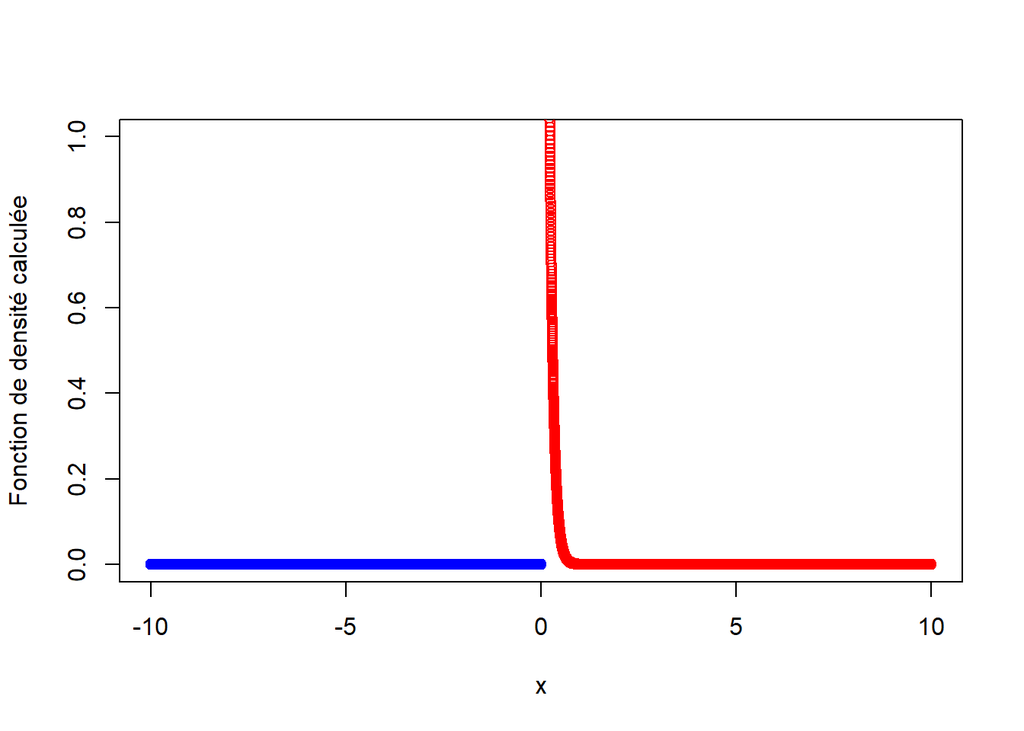

```r
# on génère des nombres entre -10 et 0 afin de représenter la première partie de f(x)
x1 = seq(from=-lim, to=0, by = .001)
y1 = rep(0, length(x1))
plot(x1,y1, xlim = c(-lim,lim),ylim=c(0,1),col="blue",xlab = "x", ylab = "Fonction de densité calculée")
# on génères des nombres entre 0 et5 afin de représenter la seconde partie de f(x)
x2 = seq(from=0, to=lim, by=.001)
points(x2, theta_test*exp(-theta_test*x2), type='b', col="red")
```

- Tracé de la fonction de densité codée par nous

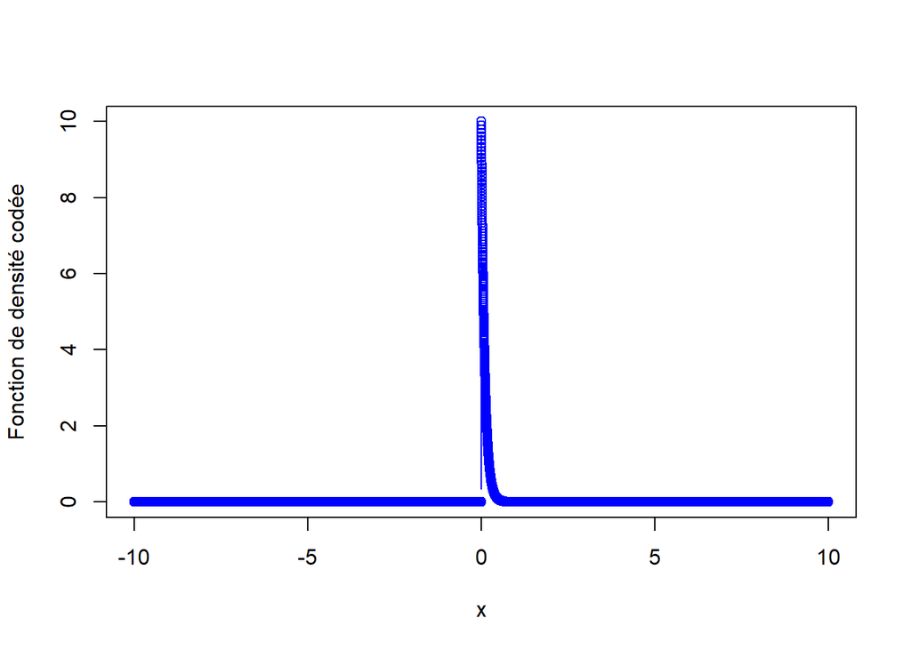

```r
# on génère des nombres dans [-10; 10]

x = seq(from=-lim, to=lim, by=.001)
y = rep(0, length(x))
# pour chaque x, on applique la fonction dEpsi
for(i in 1:length(x))
  y[i] = dEpsi(x[i], theta = theta_test)

plot(x,y, col="blue", type = "b",ylab = "Fonction de densité codée")
```

- Tracé de la fonction de densité disponible dans R

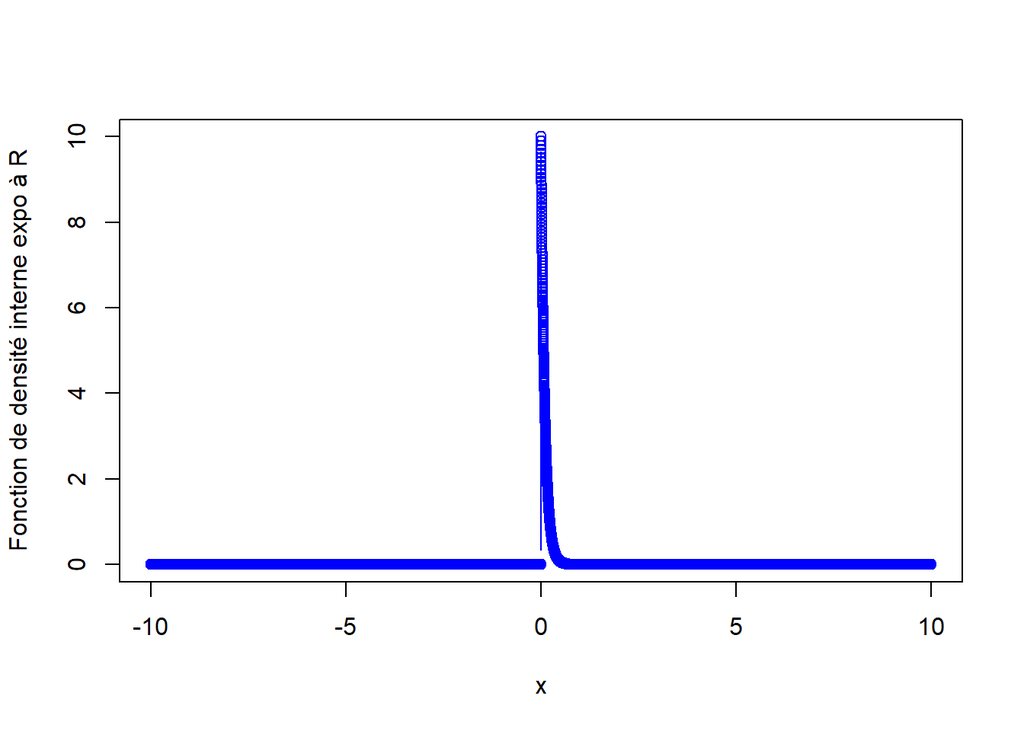

```r
# on génère toujours des valeurs entre -10 et 10 afin de faciliter la comparaison visuelle
x = seq(from = -lim, to = lim, by=.001)
plot(x, dexp(x,theta_test), type = 'b', col="blue", ylab = "Fonction de densité interne expo à R")
```

**Remarque**: L’observation des graphiques ci-dessus permet de conclure que les trois (03) types de densités représentées sont similaires. Donc le code de notre fonction de densité est conforme et peut bel et bien être utilisé pour la suite.

- Tracé de la fonction de répartition donnée (produite par nos calculs)

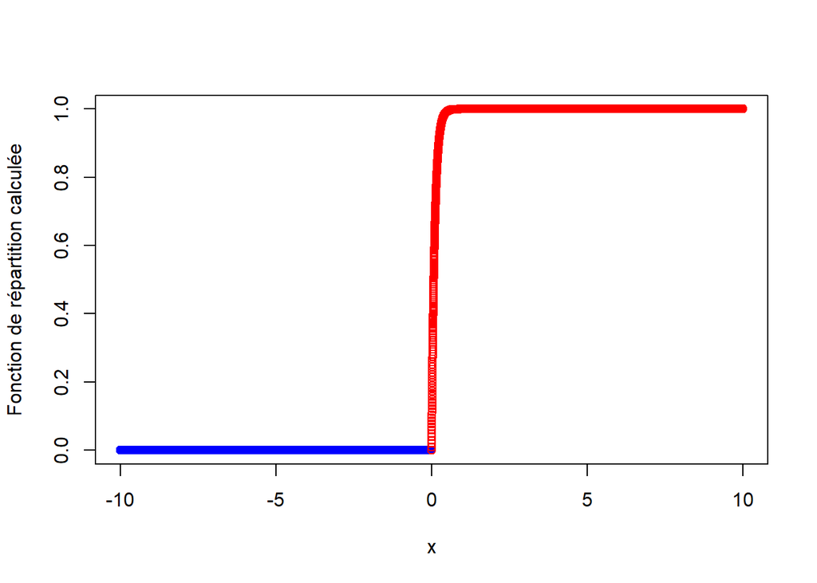

```r
# cette dernière sera découpée en 2 parties d'après nos calculs
# on construit les absices de la première partie
x1 = seq(from=-lim, to=0, by = .001)
y1 = rep(0, length(x1))
plot(x1,y1, xlim = c(-lim,lim),ylim=c(0,1),col="blue", xlab = "x", ylab = "Fonction de répartition calculée")
# on génères des nombres entre 0 et 10 afin de représenter la seconde partie de F(x)
x2 = seq(from=0, to=lim, by=.001)
points(x2, (1-exp(-x2*theta_test)), type='b', col="red")
```

```r
# on assemble enfin le tout avec des couleurs différentes afin de faciliter la distinction
```

- Tracé de la fonction de répartition codée par nous

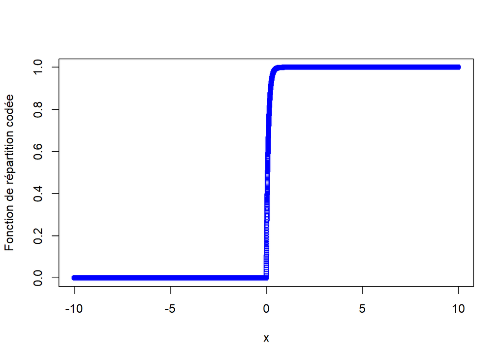

```r
# on génère des nombres dans [-10; 10]

x = seq(from=-lim, to=lim, by=.001)
y = rep(0, length(x))
# pour chaque x, on applique la fonction FEpsi
for(i in 1:length(x))
  y[i] = FEpsi(x[i], theta = theta_test)

plot(x,y, col="blue", type = "b", ylab = "Fonction de répartition codée")
```

- Tracé de la fonction de répartition disponible dans R

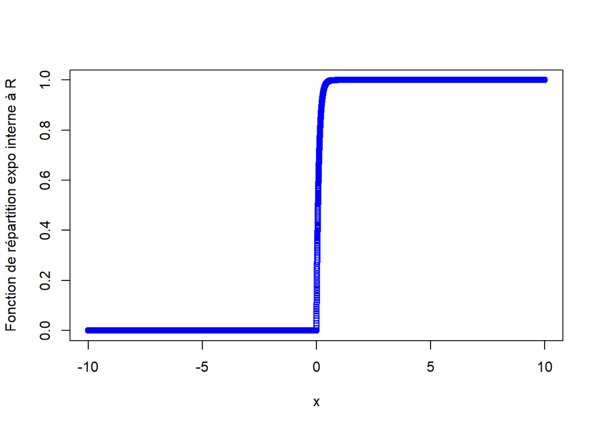

```r
# là aussi on continue de travailler dans le même intervalle
x = seq(from = -lim, to = lim, by=.001)
plot(x, pexp(x,theta_test), type = 'b', col="blue", ylab = "Fonction de répartition expo interne à R")
```

- Comparaison graphique entre notre fonction de quantiles et celle disponible dans R pour une loi exponentielle

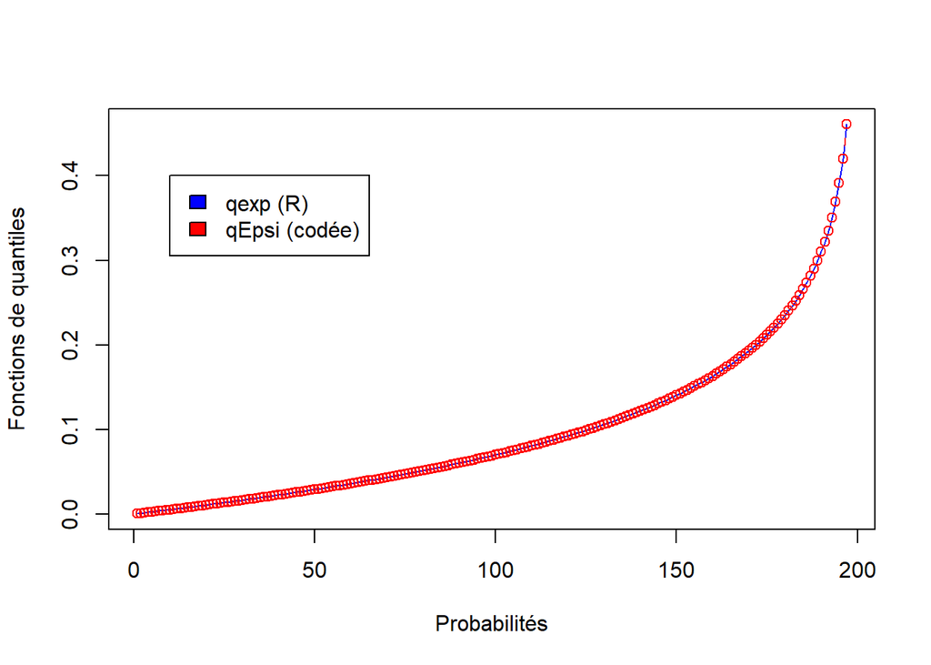

```r
# test de qBruit sur un vecteur des ordres de quantiles de 0.01 à 0.99 et un pas de 0.05
quantiles = seq(from=.01,to = .99, by = .005)
# construction de la courbe avec les quantiles internes à R
plot(qexp(quantiles,rate = theta_test),type = 'l', col="blue", xlab="Probabilités",ylab = "Fonctions de quantiles")

# On change le type de points affichés et la couleur pour une meilleure comparaison
points(qEpsi(quantiles,theta = theta_test), type = 'b', col="red")

# On ajoute une légende pour distinguer les courbes
legend(x=10,y =.4, legend = c("qexp (R)","qEpsi (codée)"), fill = c("blue","red"))
```

- Comparaison graphique entre notre fonction de probabilités et celle disponible dans R pour une loi exponentielle

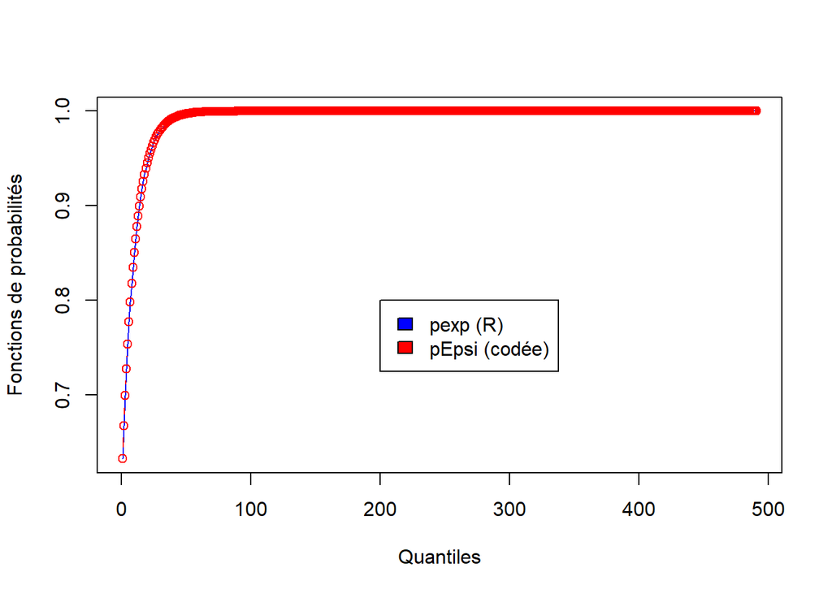

```r
q =  seq(.1,5,0.01)
## construction de la courbe avec les probabilités internes à R
plot(pexp(q, theta_test),type = 'l', col="blue", xlab="Quantiles",ylab = "Fonctions de probabilités")
# là aussi on change le motif et la couleur pour la comparaison

# On rend la fonction vectorisable afin qu'elle parcoure le vecteur q sans message d'erreur
pEpsi_vec = Vectorize(pEpsi,vectorize.args = "q")
points(pEpsi_vec(q, theta_test), type = 'b', col="red")
# On ajoute une légende pour distinguer les courbes
legend(x=200,y =.8, legend = c("pexp (R)","pEpsi (codée)"), fill = c("blue","red"))
```

**Remarque** : Dans les deux(02) cas ci-dessus de test des fonction de probabilités et de quartiles, on remarque que les deux courbs se confondent à chaque fois, ceci prouve une fois de plus que notre code reproduit aux mieux les fonction (de probabilité et de quartiles exponentielles) internes à R.

- Comparaison graphique entre notre simulateur et celui disponible dans R pour une loi exponentielle

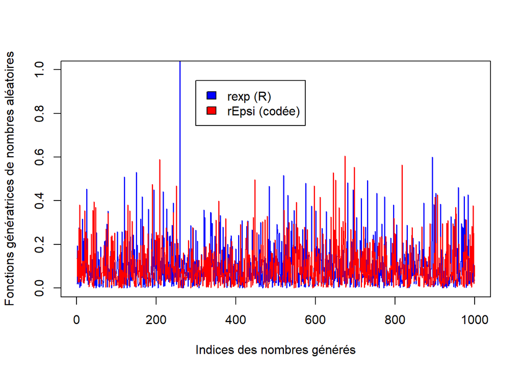

```r
# Construction d'un graphique pour une meilleure comparaison avec des valeurs générées
# Construction d'un ensemble de 10000 valeurs aléatoires suivant la loi expo de R
set.seed(numListe)
expo1 = rexp(1000, theta_test)
plot(expo1,type = 'l', col="blue",ylim=c(0,1), xlab = "Indices des nombres générés", ylab = "Fonctions génératrices de nombres aléatoires")

# Construction d'un ensemble de 10000 valeurs aléatoires suivant notre loi expo
expo2 = rEpsi(1000, theta_test)
points(expo2, type = 'l', col="red")

# On ajoute une légende pour distinguer les courbes
legend(x=300,y =.95, legend = c("rexp (R)","rEpsi (codée)"), fill = c("blue","red"))
```

**Remarque** : Mis à part quelques points isolés, les deux courbes ont la même allure et semblent être similaires dans l’ensemble, il serait intéressant de calculer les carrés des résidus (différences entre les deux valeurs élévée au carré) et construire la courbe y relative.

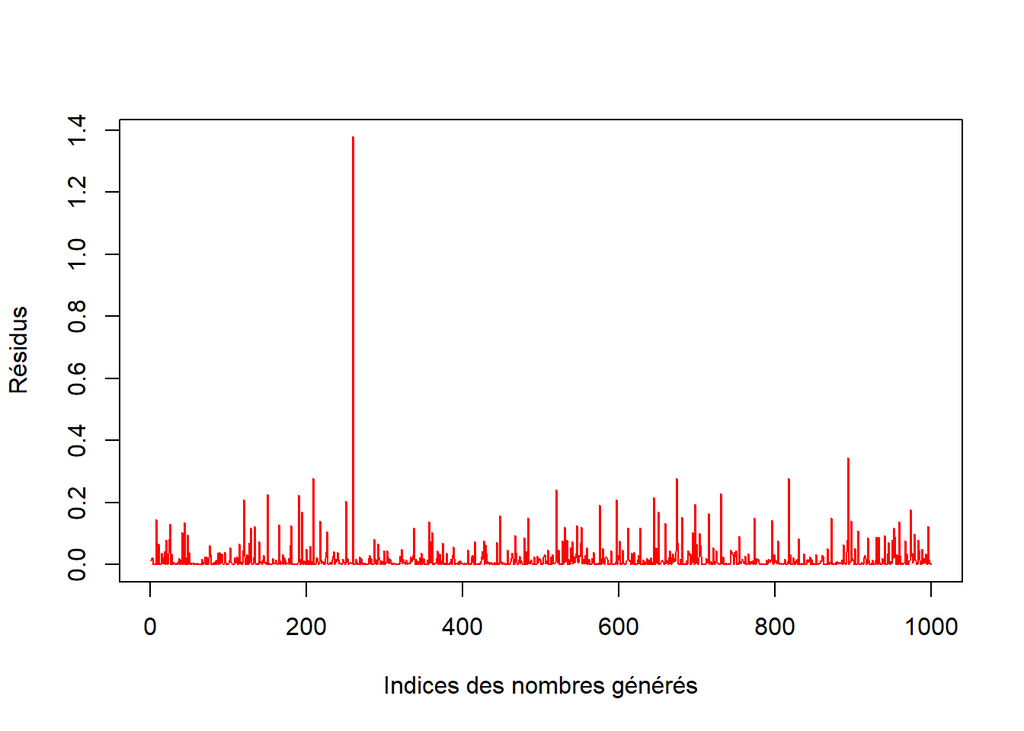

```r
# On utilise
plot((expo2-expo1)^2, type = 'l', col="red", xlab = "Indices des nombres générés", ylab="Résidus")
```

**Remarque**: Comme il fallait s’y attendre, la majorité des différences (résidus) oscillent entre 0 et 0.1.

# Utilisez ensuite le simulateur du bruit pour simuler des réalisations du modèle de croissance d’un arbre décrit plus haut.

Dans un premier temps, simulons notre modèle sans inclure le bruit $\epsilon$ afin de mieux choisir le paramètre $\theta$, par la suite.

### Simulation sans le bruit

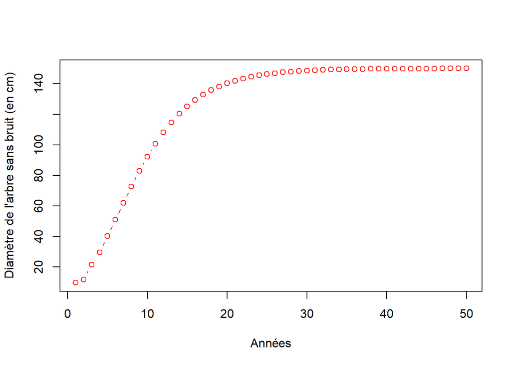

```r
epsi_sans_bruit = rep(1,50)

# On Construit enfin notre table avec les tailles des arbres
X_sans_bruit = generateTrajectory(epsi = epsi_sans_bruit)

# On construit un graphique pour la visualisation
plot(X_sans_bruit, type = "b", col="red", xlab = "Années", ylab = "Diamètre de l'arbre sans bruit (en cm)")
```

**Remarque** : Sans l’inclusion du bruit, on voit bel et bien que notre modèle simule le comportement normal de la croissance d’un arbre. En effet, l’abre grandit au fil des années.

Afin de déterminer quel bruit est adéquat, nous devons simuler plusieurs trajectoires du modèle avec différentes valeurs du bruit et choisir celui qui est le plus en accord avec la description initiale données plus haut.

### Bruit de l’ordre des unités

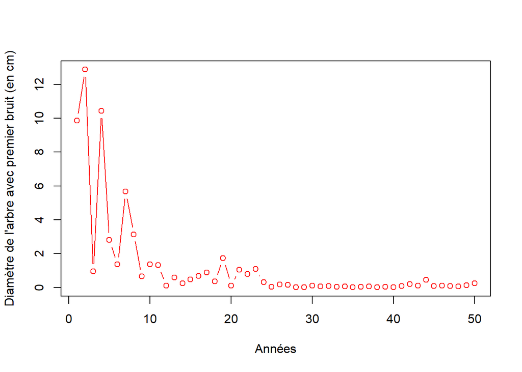

```r
#initialisation du seed
set.seed(numListe)
# pour une valeur de theta égale à 5 par exemple
thetaUnite = 5

# vecteur de bruit pour theta valant 5
epsi_bruitUnite = rEpsi(k_max, theta = thetaUnite)

# On Construit enfin notre tableau avec les tailles des arbres
X_avec_bruitUnite = generateTrajectory(epsi = epsi_bruitUnite)

# On construit un graphique pour la visualisation
plot(X_avec_bruitUnite, type = "b", col="red", xlab = "Années", ylab = "Diamètre de l'arbre avec premier bruit (en cm)")
```

### Bruit de l’ordre des dizaines

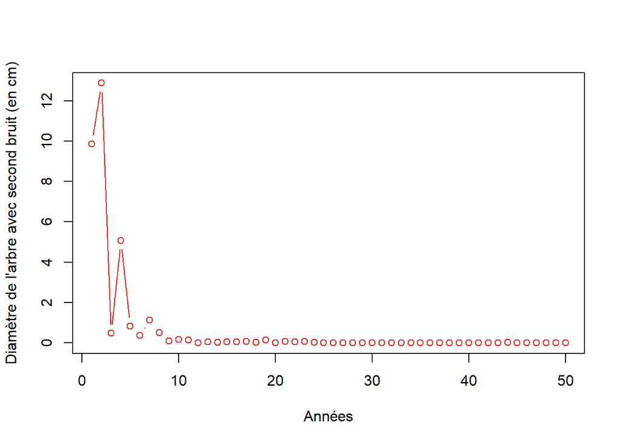

```r
set.seed(numListe)
# pour une valeur de theta égale à 10 par exemple
thetaDiz = 10

# vecteur de bruit pour theta valant 10
epsi_bruitDiz = rEpsi(k_max, theta = thetaDiz)

# On Construit enfin notre tableau avec les tailles des arbres
X_avec_bruitDiz = generateTrajectory(epsi = epsi_bruitDiz)

# On construit un graphique pour la visualisation
plot(X_avec_bruitDiz, type = "b", col="red", xlab = "Années", ylab = "Diamètre de l'arbre avec second bruit (en cm)")
```

**Remarque :** Comme on pouvait s’y attendre, en accord avec la formule de $F^{-1}(x)$, plus $\theta$ est grand et supérieur à 1, plus le bruit a tendance à prendre des valeurs inférieures à 1, ce qui diminue le diamètre de l’abre au fil des années(ce comportement n’est pas en accord avec la nature). Il ne serait pas opportun de choisir des valeurs de $\theta$ au delà des unités.

### Bruit decimal valant 1.5

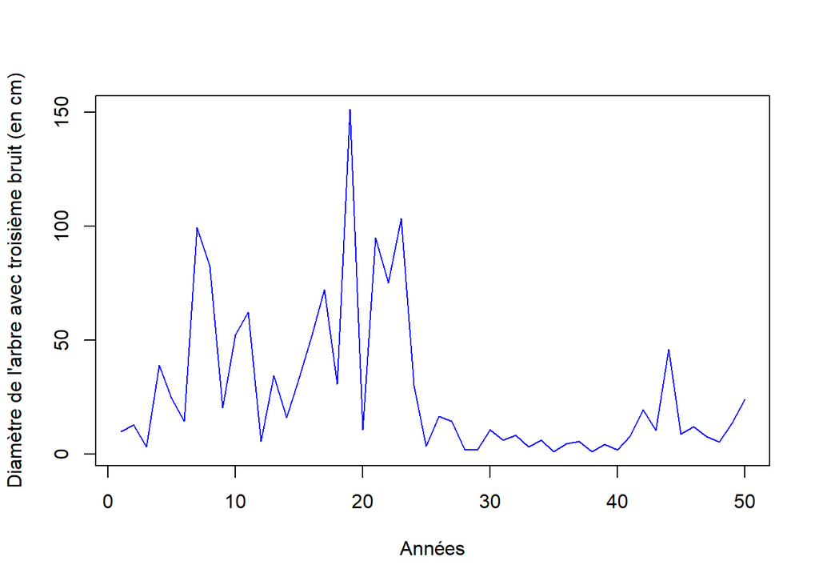

```r
set.seed(numListe)
# pour une valeur de theta égale à 1.5 par exemple
theta15 = 1.50

# vecteur de bruit pour theta valant 1.5
epsi_bruit15 = rEpsi(k_max, theta = theta15)

# On Construit enfin notre tableau avec les tailles des arbres
X_avec_bruit15 = generateTrajectory(epsi = epsi_bruit15)

# On construit un graphique pour la visualisation
plot(X_avec_bruit15, type = "l", col="blue", xlab = "Années", ylab = "Diamètre de l'arbre avec troisième bruit (en cm)")
```

### Bruit décimal supérieur à 1.5

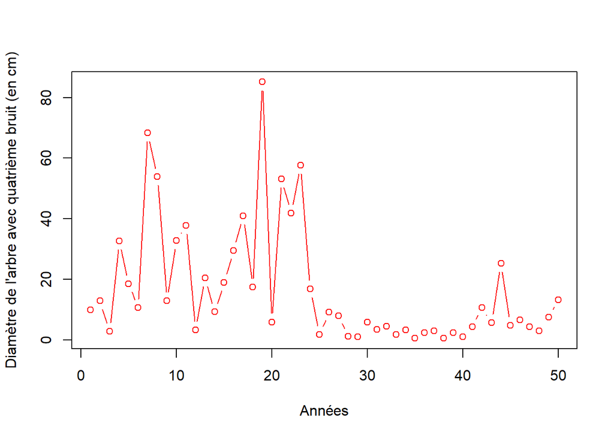

```r
set.seed(numListe)
# pour une valeur de theta supérieure à 1.5
thetaSup15 = 1.75

# vecteur de bruit pour theta supérieur 1.5
epsi_bruitSup15 = rEpsi(k_max, theta = thetaSup15)

# On Construit enfin notre tableau avec les tailles des arbres
X_avec_bruitSup15 = generateTrajectory(epsi = epsi_bruitSup15)

# On construit un graphique pour la visualisation
plot(X_avec_bruitSup15, type = "b", col="red", xlab = "Années", ylab = "Diamètre de l'arbre avec quatrième bruit (en cm)")
```

### Bruit décimal inférieur à 1.5

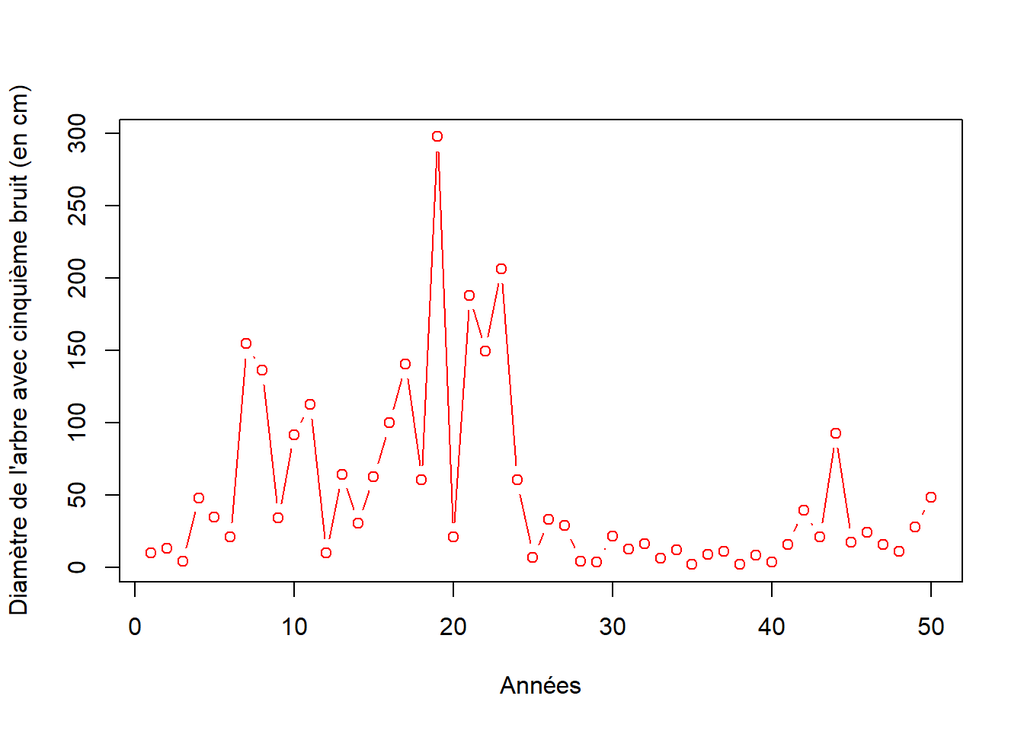

```r
set.seed(numListe)
# pour une valeur de theta inférieure à 1.5
thetaInf15 = 1.25

# vecteur de bruit pour theta inférieure 1.5
epsi_bruitInf15 = rEpsi(k_max, theta = thetaInf15)

# On Construit enfin notre tableau avec les tailles des arbres
X_avec_bruitInf15 = generateTrajectory(epsi = epsi_bruitInf15)

# On construit un graphique pour la visualisation
plot(X_avec_bruitInf15, type = "b", col="red", xlab = "Années", ylab = "Diamètre de l'arbre avec cinquième bruit (en cm)")
```

# D’après votre simulation sur les 50 années, en quelle année, l’abre atteindra la plus grande valeur? Quelle est cette valeur? Vous préciserez aussi la plus grande variation entre deux années selon vos simulations et l’année à laquelle on obersve cette marge.

D’après nos simulations, on peut retenir le modèle avec $\theta = 1.5$. L’année de plus grande valeur est 19, c’est à dire si l’année initiale est 2023, l’abre aura sa taille maximale en 2042. La valeur maximale ainsi atteinte est : 151.13 cm.

```r
# il est nécessaire de créer le vecteur contenant les variations de taille entre deux années adjacentes
# on utilise la fonction diff
X_avec_bruit15Diff = diff(X_avec_bruit15)
```

La plus grande variation entre deux années est : 120.38 cm et l’année d’observation de cette marge est : 18, c’est à dire que si on fixait 2023 comme année initiale alors cette marge sera observée en : 2041.

# Simuler enfin 50 réalisations de ce modèle sur les 50 années et les représenter toutes sur le même graphique.

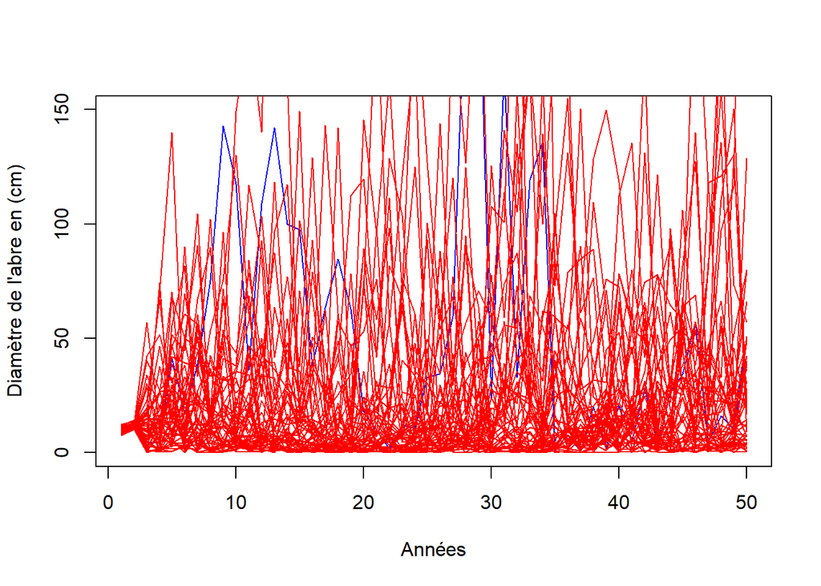

```r
# ici, on initialise pas le seed afin d'avoir des trajectoires différentes
# Matrice des bruits
M_simulations = matrix(0, nrow = k_max, ncol = k_max)

# construction de 50 trajectoires différentes
for(i in 1:k_max)
  M_simulations[i,] = generateTrajectories(theta = 1.5)

plot(M_simulations[1,], type = 'l',ylim = c(0,150) ,col="blue", xlab = "Années", ylab="Diamètre de l'abre en (cm)")
for(i in 2:k_max){
  points(M_simulations[i,], type = 'l', col="red")
}
```

**Remarque :** On remarque que les trajectoires générées par ce modèle se confondent en points et en allure à quelques détails près. Si on se réfère aux conditions normales, la courbe illustrant ce modèle évolue en dent de scie, **ce qui est contraire à la croissance naturelle d’un arbre**, même s’il arrive que la croissance de ce dernier soit ralentie par des facteurs climatiques pour ne citer que ceux là, **la taille de son diamètre ne peut décroitre de manière aussi sévère d’une année à l’autre tel que le montre ces courbes**.

**Conclusion** : ce modèle ne reflète pas la réalité attendue et il n’est non plus acceptable, malgré la fait qu’on atteigne sensiblement le diamètre maximal pour une année précise.

# Question subsidiaire

**Remarque :** On remarque que le bruit choisi a tendance soit à sous-estimer la croissance de l’arbre. Dans la suite, nous devons le normaliser (le bruit) afin de produire un modèle final cohérent et en accord avec la nature. Pour ce faire, nous devons implémenter une fonction de normalisation qui se chargera de mettre dans le bon intervalle de valeurs les différentes valeurs du vecteur de bruit au fil des années. D’après la correction du TP 2021, nous avons vu qu’un bruit $lognormal$ avec une moyenne égale à l’unité et de $.02$ permettait d’avoir un bruit adéquat. Il est donc question de récupérer le minimum et le maximum des valeurs de cette série de nombres générés à partir de ladite loi lognormale. Ces extrêmas serviront à normaliser les valeurs de notre bruit pour tout $\theta \neq 0$.

Dans l’histogramme ci-dessous, on peut visualiser les valeurs prises par cette la loi log normale

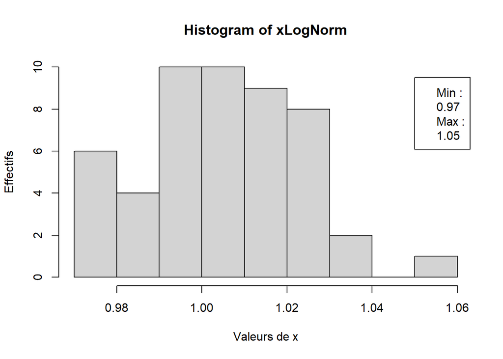

```r
# construction de l'histogramme de 50 valeurs générées à partir de la loi lognormale 0 et .02
set.seed(numListe)
xLogNorm = rlnorm(k_max,0,.02)
hist(xLogNorm, xlab = "Valeurs de x", ylab = "Effectifs")
lmin = c("Min :",round(min(xLogNorm),2))
lmax = c("Max :",round(max(xLogNorm),2))
legend(x=1.05,y =9.5, legend = c(lmin,lmax))
```

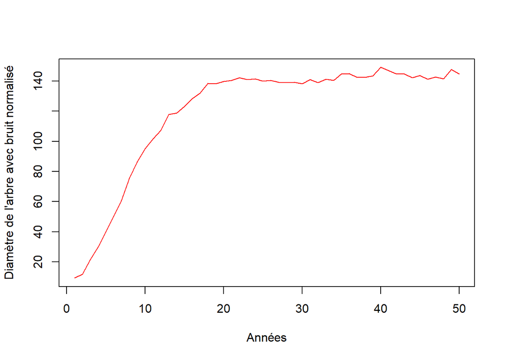

```r
# Construction d'une simulation avec le bruit normalisé
# pour une valeur de theta égale à 1.5 par exemple
thetaNorm = 1.5

# On initialise pas le seed afin de voir comment la courbe peut changer malgré un bruit statique
# vecteur de bruit non normalisé généré avec notre générateur aléatoire
epsi_bruit1 = rEpsi(k_max, theta = thetaNorm)
epsi_bruit1_norm = normBruit(X = epsi_bruit1, a = min(xLogNorm), b = max(xLogNorm))

# On Construit enfin notre tableau avec les tailles des arbres
X_avec_bruitNorm  = generateTrajectory(epsi = epsi_bruit1_norm)

# On construit un graphique pour la visualisation
plot(X_avec_bruitNorm, type = "l", col="red", xlab = "Années", ylab = "Diamètre de l'arbre avec bruit normalisé")
```

Avec cette normalisation du bruit, on se rapproche une peu plus de la réalité. D’après cette derniièrue simulation, l’année de plus grande valeur est 40, c’est à dire si l’année initiale est 2023, l’abre aura sa taille maximale en 2063. La valeur maximale ainsi atteinte est : 149.1 cm.